# Lab 3

Author

Olivia Roberts

```r
library(ggplot2)
library(leaflet)
library(lubridate)
```

**Question 1**

```r
# Read in the data
met <- read.csv("met_all.gz")
```

**Question 2**

```r
# Check the dimensions, headers, footers
dim(met)
```

```
[1] 2377343      30
```

Answer: There are 2377343 rows and 30 columns.

**Question 3**

```r
# Variables
str(met)
```

```
'data.frame':   2377343 obs. of  30 variables:
 $ USAFID           : int  690150 690150 690150 690150 690150 690150 690150 690150 690150 690150 ...
 $ WBAN             : int  93121 93121 93121 93121 93121 93121 93121 93121 93121 93121 ...
 $ year             : int  2019 2019 2019 2019 2019 2019 2019 2019 2019 2019 ...
 $ month            : int  8 8 8 8 8 8 8 8 8 8 ...
 $ day              : int  1 1 1 1 1 1 1 1 1 1 ...
 $ hour             : int  0 1 2 3 4 5 6 7 8 9 ...
 $ min              : int  56 56 56 56 56 56 56 56 56 56 ...
 $ lat              : num  34.3 34.3 34.3 34.3 34.3 34.3 34.3 34.3 34.3 34.3 ...
 $ lon              : num  -116 -116 -116 -116 -116 ...
 $ elev             : int  696 696 696 696 696 696 696 696 696 696 ...
 $ wind.dir         : int  220 230 230 210 120 NA 320 10 320 350 ...
 $ wind.dir.qc      : chr  "5" "5" "5" "5" ...
 $ wind.type.code   : chr  "N" "N" "N" "N" ...
 $ wind.sp          : num  5.7 8.2 6.7 5.1 2.1 0 1.5 2.1 2.6 1.5 ...
```

[output cut: 16 more lines]

Answer: Many of the variables are integers, numbers, and characters.

**Question 4**

```r
# Key variables
table(met$year, met$day)
```

```
           1     2     3     4     5     6     7     8     9    10    11    12
  2019 75975 75923 76915 76594 76332 76734 77677 77766 75366 75450 76187 75052

          13    14    15    16    17    18    19    20    21    22    23    24
  2019 76906 77852 76217 78015 78219 79191 76709 75527 75786 78312 77413 76965

          25    26    27    28    29    30    31
  2019 76806 79114 79789 77059 71712 74931 74849
```

```r
table(met$hour)
```

```
     0      1      2      3      4      5      6      7      8      9     10
 99434  93482  93770  96703 110504 112128 106235 101985 100310 102915 101880
    11     12     13     14     15     16     17     18     19     20     21
100470 103605  97004  96507  97635  94942  94184 100179  94604  94928  96070
    22     23
 94046  93823
```

```r
summary(met$temp)
```

```
   Min. 1st Qu.  Median    Mean 3rd Qu.    Max.    NA's
 -40.00   19.60   23.50   23.59   27.80   56.00   60089
```

```r
summary(met$elev)
```

```
   Min. 1st Qu.  Median    Mean 3rd Qu.    Max.
  -13.0   101.0   252.0   415.8   400.0  9999.0
```

```r
summary(met$wind.sp)
```

```
   Min. 1st Qu.  Median    Mean 3rd Qu.    Max.    NA's
  0.000   0.000   2.100   2.459   3.600  36.000   79693
```

```r
# Replace elevations with 9999.0 as NA
met$elev[met$elev == 9999.0] <- NA
# Remove -40C temperature points
met <- met[met$temp != -40, ]
# Remove NA temperature points
met <- met[!is.na(met$temp), ]
```

Answer: There is one year (2019), 31 days, and 24 hours (coded as 0-23). Temp ranges from -40.00 to 56.00, elevation ranges from -13.0 to 9999.0 (which is an indicator for missing), and wind speed ranges from 0.000 to 36.000. When changing 9999.0 to NAs in elevation, the highest weather station is actually at 4113 elevation. After removing the -40C temperature points, the new lowest temperature is -17.2C.

**Question 5**

```r
summary(met$elev)
```

```
   Min. 1st Qu.  Median    Mean 3rd Qu.    Max.    NA's
  -13.0   101.0   252.0   414.3   400.0  4113.0     182
```

```r
str(met)
```

```
'data.frame':   2317218 obs. of  30 variables:
 $ USAFID           : int  690150 690150 690150 690150 690150 690150 690150 690150 690150 690150 ...
 $ WBAN             : int  93121 93121 93121 93121 93121 93121 93121 93121 93121 93121 ...
 $ year             : int  2019 2019 2019 2019 2019 2019 2019 2019 2019 2019 ...
 $ month            : int  8 8 8 8 8 8 8 8 8 8 ...
 $ day              : int  1 1 1 1 1 1 1 1 1 1 ...
 $ hour             : int  0 1 2 3 4 5 6 7 8 9 ...
 $ min              : int  56 56 56 56 56 56 56 56 56 56 ...
 $ lat              : num  34.3 34.3 34.3 34.3 34.3 34.3 34.3 34.3 34.3 34.3 ...
 $ lon              : num  -116 -116 -116 -116 -116 ...
 $ elev             : int  696 696 696 696 696 696 696 696 696 696 ...
 $ wind.dir         : int  220 230 230 210 120 NA 320 10 320 350 ...
 $ wind.dir.qc      : chr  "5" "5" "5" "5" ...
 $ wind.type.code   : chr  "N" "N" "N" "N" ...
 $ wind.sp          : num  5.7 8.2 6.7 5.1 2.1 0 1.5 2.1 2.6 1.5 ...
```

[output cut: 16 more lines]

```r
met[met$temp == -17.2, ]
```

```
        USAFID WBAN year month day hour min    lat    lon elev wind.dir
1203053 722817 3068 2019     8   1    0  56 38.767 -104.3 1838      190
1203055 722817 3068 2019     8   1    1  56 38.767 -104.3 1838      180
1203128 722817 3068 2019     8   3   11  56 38.767 -104.3 1838       NA
1203129 722817 3068 2019     8   3   12  56 38.767 -104.3 1838       NA
1203222 722817 3068 2019     8   6   21  56 38.767 -104.3 1838      280
1203225 722817 3068 2019     8   6   22  56 38.767 -104.3 1838      240
        wind.dir.qc wind.type.code wind.sp wind.sp.qc ceiling.ht ceiling.ht.qc
1203053           5              N     7.2          5         NA             9
1203055           5              N     7.7          5         NA             9
1203128           9              C     0.0          5         NA             9
1203129           9              C     0.0          5         NA             9
1203222           5              N     2.6          5         NA             9
1203225           5              N     7.7          5         NA             9
        ceiling.ht.method sky.cond vis.dist vis.dist.qc vis.var vis.var.qc
1203053                 9        N       NA           9       N          5
1203055                 9        N       NA           9       N          5
1203128                 9        N       NA           9       N          5
1203129                 9        N       NA           9       N          5
1203222                 9        N       NA           9       N          5
1203225                 9        N       NA           9       N          5
         temp temp.qc dew.point dew.point.qc atm.press atm.press.qc rh
1203053 -17.2       5        NA            9        NA            9 NA
1203055 -17.2       5        NA            9        NA            9 NA
1203128 -17.2       5        NA            9        NA            9 NA
1203129 -17.2       5        NA            9        NA            9 NA
1203222 -17.2       5        NA            9        NA            9 NA
1203225 -17.2       5        NA            9        NA            9 NA
```

```r
met <- met[met$temp != -17.2, ]

met[met$temp == -17, ]
```

```
        USAFID  WBAN year month day hour min    lat      lon elev wind.dir
1105455 722518 12974 2019     8  11   23  56 27.901  -98.052   78      150
1105457 722518 12974 2019     8  12    1  56 27.901  -98.052   78      150
1105459 722518 12974 2019     8  12    3  56 27.901  -98.052   78      160
1203054 722817  3068 2019     8   1    1   6 38.767 -104.300 1838      180
1203221 722817  3068 2019     8   6   21  39 38.767 -104.300 1838      210
1203223 722817  3068 2019     8   6   22  32 38.767 -104.300 1838      260
1203224 722817  3068 2019     8   6   22  41 38.767 -104.300 1838       NA
1203226 722817  3068 2019     8   6   23   3 38.767 -104.300 1838      210
        wind.dir.qc wind.type.code wind.sp wind.sp.qc ceiling.ht ceiling.ht.qc
1105455           1              N     8.8          1      22000             1
1105457           1              N     8.2          1      22000             1
1105459           1              N     5.1          1      22000             1
1203054           5              N     5.1          5         NA             9
1203221           5              N     1.5          5         NA             9
```

[output cut: 21 more lines]

```r
met <- met[met$temp != -17, ]

met[met$temp == -3, ]
```

```
        USAFID  WBAN year month day hour min    lat      lon elev wind.dir
2370758 726764 94163 2019     8  27   11  50 44.683 -111.116 2025       NA
2370759 726764 94163 2019     8  27   12  10 44.683 -111.116 2025       NA
2370760 726764 94163 2019     8  27   12  30 44.683 -111.116 2025       NA
2370761 726764 94163 2019     8  27   12  50 44.683 -111.116 2025       NA
        wind.dir.qc wind.type.code wind.sp wind.sp.qc ceiling.ht ceiling.ht.qc
2370758           9              C       0          5      22000             5
2370759           9              C       0          5      22000             5
2370760           9              C       0          5      22000             5
2370761           9              C       0          5      22000             5
        ceiling.ht.method sky.cond vis.dist vis.dist.qc vis.var vis.var.qc temp
2370758                 9        N    16093           5       N          5   -3
2370759                 9        N    16093           5       N          5   -3
2370760                 9        N    16093           5       N          5   -3
2370761                 9        N    16093           5       N          5   -3
        temp.qc dew.point dew.point.qc atm.press atm.press.qc       rh
2370758       C        -5            C        NA            9 86.26537
2370759       5        -4            5        NA            9 92.91083
2370760       5        -4            5        NA            9 92.91083
2370761       C        -4            C        NA            9 92.91083
```

```r
met[met$temp == 56, ]
```

```
      USAFID  WBAN year month day hour min    lat      lon elev wind.dir
42403 720267 23224 2019     8  26   11  15 38.955 -121.081  467       NA
      wind.dir.qc wind.type.code wind.sp wind.sp.qc ceiling.ht ceiling.ht.qc
42403           9              C       0          5      22000             5
      ceiling.ht.method sky.cond vis.dist vis.dist.qc vis.var vis.var.qc temp
42403                 9        N    16093           5       N          5   56
      temp.qc dew.point dew.point.qc atm.press atm.press.qc rh
42403       5        NA            9        NA            9 NA
```

```r
met <- met[met$temp != 56, ]
summary(met$temp)
```

```
   Min. 1st Qu.  Median    Mean 3rd Qu.    Max.
  -3.00   19.60   23.50   23.59   27.80   54.40
```

Answer: The max elevation of 4113.0 meters and the min elevation of -13 meters seem reasonable, since some places are a bit below sea level and the high reading could plausibly be a weather station on top of a mountain range. The -17.2C temperature readings are all from a station in Colorado, and it does not really make sense to get readings that low in Colorado in August at relatively low elevation. There are also -17C temperature readings in August in Texas and Colorado that do not make sense. The highest recorded temperature (56) is in northern California in August and is higher than the highest recorded temperature in that area, so I removed that one too.

**Question 6**

```r
# Correlation between temperature and wind speed in station with max elevation
summary(met$elev)
```

```
   Min. 1st Qu.  Median    Mean 3rd Qu.    Max.    NA's
  -13.0   101.0   252.0   414.3   400.0  4113.0     182
```

```r
elev <- met[met$elev == 4113, ]
cor(elev$temp, elev$hour, use = "complete.obs")
```

```
[1] 0.4397261
```

```r
cor(elev$wind.sp, elev$hour, use = "complete.obs")
```

```
[1] 0.08807315
```

```r
cor(elev$temp, elev$day, use = "complete.obs")
```

```
[1] -0.003857766
```

```r
cor(elev$wind.sp, elev$day, use = "complete.obs")
```

```
[1] 0.3643079
```

Answer: There is a positive correlation between temp and hour and wind speed and day. There is a slight positive correlation between wind speed and hour and a slight negative correlation between temp and day.

**Question 7**

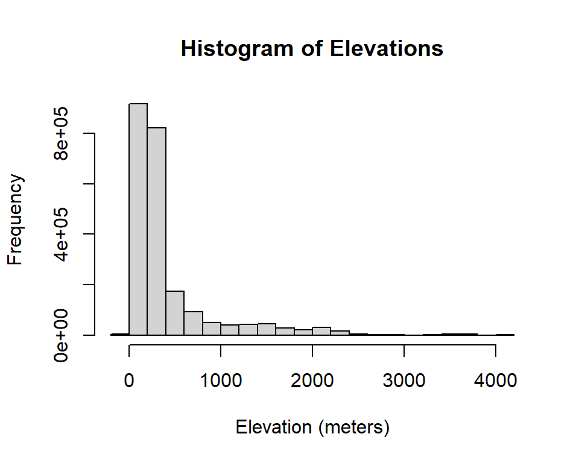

```r
hist(met$elev, main="Histogram of Elevations", xlab="Elevation (meters)")
```

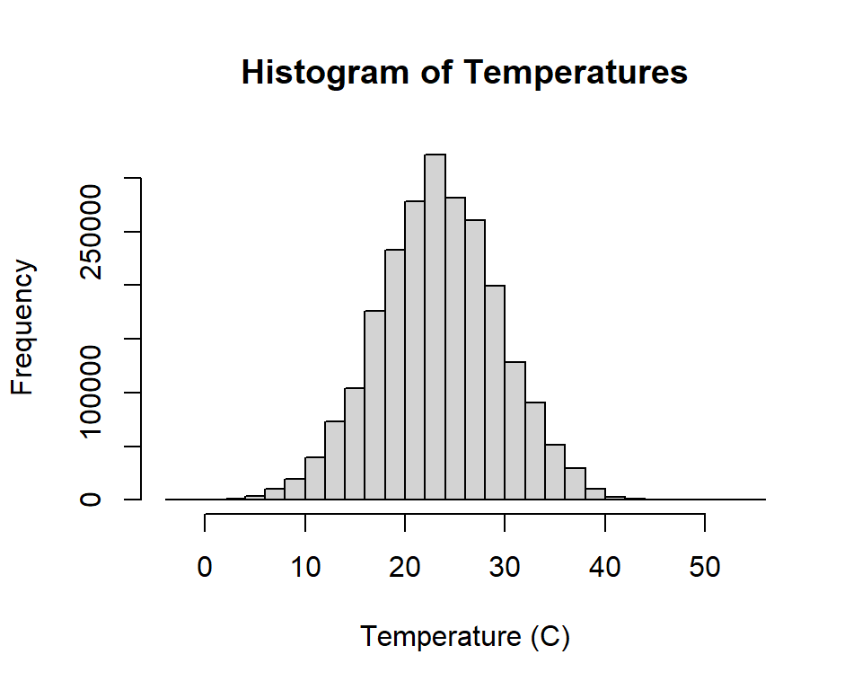

```r
hist(met$temp, main="Histogram of Temperatures", xlab="Temperature (C)")
```

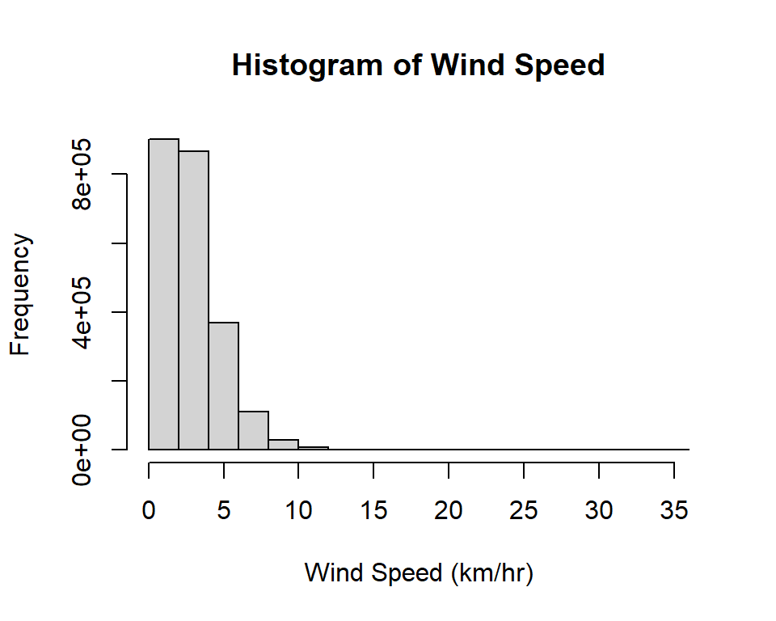

```r
hist(met$wind.sp, main="Histogram of Wind Speed", xlab="Wind Speed (km/hr)")
```

```r
leaflet(elev) %>%
  addProviderTiles('OpenStreetMap') %>%
  addCircles(lat=~lat,lng=~lon, opacity=1, fillOpacity=1, radius=100)
```

[interactive chart not shown]

```r
elev$date <- with(elev, ymd_h(paste(year, month, day, hour, sep= ' ')))
summary(elev$date)
```

```
                 Min.               1st Qu.                Median
"2019-08-01 00:00:00" "2019-08-08 11:00:00" "2019-08-16 22:00:00"
                 Mean               3rd Qu.                  Max.
"2019-08-16 14:09:56" "2019-08-24 11:00:00" "2019-08-31 22:00:00"
                 NA's
                "182"
```

```r
elev <- elev[order(elev$date), ]
head(elev)
```

```
       USAFID WBAN year month day hour min  lat      lon elev wind.dir
221697 720385  419 2019     8   1    0  36 39.8 -105.766 4113      170
221698 720385  419 2019     8   1    0  54 39.8 -105.766 4113      100
221699 720385  419 2019     8   1    1  12 39.8 -105.766 4113       90
221700 720385  419 2019     8   1    1  35 39.8 -105.766 4113      110
221701 720385  419 2019     8   1    1  53 39.8 -105.766 4113      120
221702 720385  419 2019     8   1    2  12 39.8 -105.766 4113      120
       wind.dir.qc wind.type.code wind.sp wind.sp.qc ceiling.ht ceiling.ht.qc
221697           5              N     8.8          5       1372             5
221698           5              N     2.6          5       1372             5
221699           5              N     3.1          5       1981             5
221700           5              N     4.1          5       2134             5
221701           5              N     4.6          5       2134             5
221702           5              N     6.2          5      22000             5
       ceiling.ht.method sky.cond vis.dist vis.dist.qc vis.var vis.var.qc temp
```

[output cut: 20 more lines]

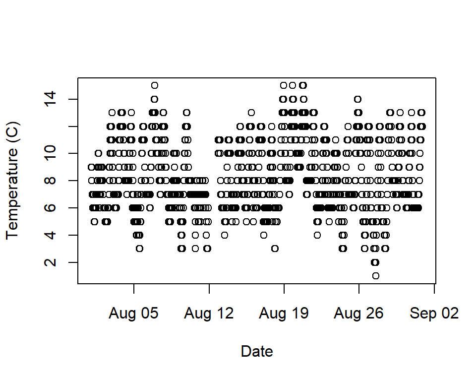

```r
plot(elev$date, elev$temp, xlab="Date", ylab="Temperature (C)")
```

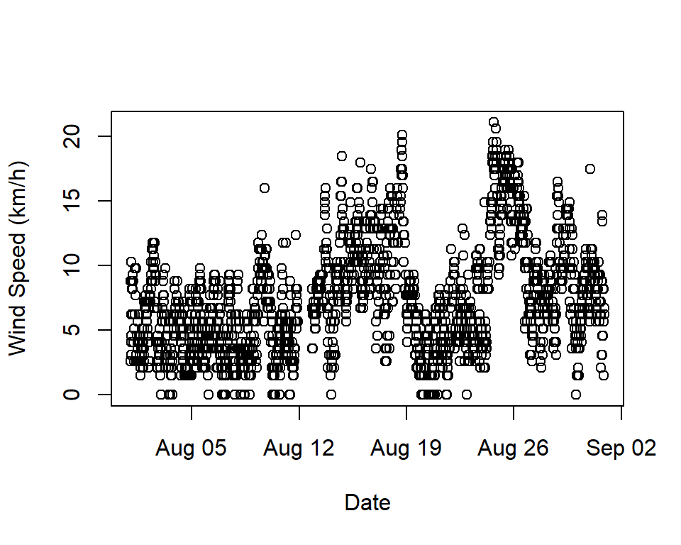

```r
plot(elev$date, elev$wind.sp, xlab="Date", ylab="Wind Speed (km/h)")
```